# ML Project

## Load data and preprocess

I load the data with read.csv and since some columns are full of NA I remove them. Finally I also remove timestamps, user_name and the window variables.

```r
data <- read.csv('pml-training.csv', na.strings = c("", "NA"))
nas <- apply(data, 2, function(y) sum(length(which(is.na(y)))))
data <- data[, nas == 0]
data <- select(data, -contains('timestamp'), -X, -user_name, -contains('window'))

test_data <- read.csv('pml-testing.csv', na.strings = c("", "NA"))
test_data <- test_data[, nas == 0]
test_data <- select(test_data, -contains('timestamp'), -X, -user_name, -contains('window'))
```

```r
set.seed(1234)
inTrain <- createDataPartition(y=data$classe, p=0.8, list=FALSE)
testing <- data[-inTrain,]
training <- data[inTrain,]
```

I have 15699 observations in the training set and 3923 in the testing set.

## Model fitting

Using the caret packet I fit a model using boosting and 5-fold cross validation.

```r
fitControl <- trainControl(method = "cv", number = 5)
modelFit <- train(classe~., data = training,
                  method = "gbm", trControl = fitControl,
                  verbose = FALSE)
modelFit
```

```
## Stochastic Gradient Boosting
##
## 15699 samples
##    52 predictor
##     5 classes: 'A', 'B', 'C', 'D', 'E'
##
## No pre-processing
## Resampling: Cross-Validated (5 fold)
## Summary of sample sizes: 12558, 12562, 12558, 12560, 12558
## Resampling results across tuning parameters:
##
##   interaction.depth  n.trees  Accuracy   Kappa      Accuracy SD
##   1                   50      0.7492821  0.6820577  0.008255236
##   1                  100      0.8237460  0.7768831  0.006645886
##   1                  150      0.8517101  0.8123926  0.003862390
##   2                   50      0.8534298  0.8142612  0.006068870
##   2                  100      0.9062365  0.8813514  0.001503532
##   2                  150      0.9287223  0.9097934  0.002260354
##   3                   50      0.8935602  0.8652274  0.003028126
##   3                  100      0.9420976  0.9267292  0.002849014
##   3                  150      0.9610804  0.9507578  0.003372414
##   Kappa SD
##   0.010505202
##   0.008510325
##   0.004917712
##   0.007712416
##   0.001902895
##   0.002870302
##   0.003838033
##   0.003595834
##   0.004257401
##
## Tuning parameter 'shrinkage' was held constant at a value of 0.1
##
## Tuning parameter 'n.minobsinnode' was held constant at a value of 10
## Accuracy was used to select the optimal model using  the largest value.
## The final values used for the model were n.trees = 150,
##  interaction.depth = 3, shrinkage = 0.1 and n.minobsinnode = 10.
```

### Model accuracy

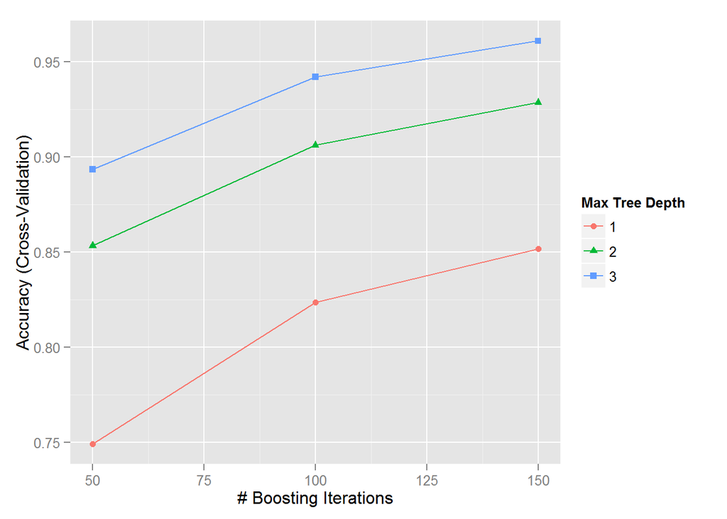

```r
ggplot(modelFit)
```

## Model evaluation

Using the part of the data that I reserved for testing I can evaluate the out of sample error more precisely than using the cross validation error:

```r
prediction <- predict(modelFit, testing)
confusionMatrix(testing$classe, prediction)
```

```
## Confusion Matrix and Statistics
##
##           Reference
## Prediction    A    B    C    D    E
##          A 1097   13    1    4    1
##          B   24  724   11    0    0
##          C    0   23  654    7    0
##          D    0    2   20  617    4
##          E    4    9    4    7  697
##
## Overall Statistics
##
##                Accuracy : 0.9658
##                  95% CI : (0.9597, 0.9713)
##     No Information Rate : 0.2868
##     P-Value [Acc > NIR] : < 2.2e-16
##
##                   Kappa : 0.9568
##  Mcnemar's Test P-Value : 7.232e-05
##
## Statistics by Class:
##
##                      Class: A Class: B Class: C Class: D Class: E
## Sensitivity            0.9751   0.9390   0.9478   0.9717   0.9929
## Specificity            0.9932   0.9889   0.9907   0.9921   0.9925
## Pos Pred Value         0.9830   0.9539   0.9561   0.9596   0.9667
## Neg Pred Value         0.9900   0.9851   0.9889   0.9945   0.9984
## Prevalence             0.2868   0.1965   0.1759   0.1619   0.1789
## Detection Rate         0.2796   0.1846   0.1667   0.1573   0.1777
## Detection Prevalence   0.2845   0.1935   0.1744   0.1639   0.1838
## Balanced Accuracy      0.9842   0.9640   0.9693   0.9819   0.9927
```

From this data we can be confident that the model is very accurate.

## Prediction

Finally I use the model to predict the class fro the 20 observations in the provided test data:

```r
answers <- predict(modelFit, test_data)
answers
```

```
##  [1] B A B A A E D B A A B C B A E E A B B B
## Levels: A B C D E
```

```r
pml_write_files = function(x){
  n = length(x)
  for(i in 1:n){
    filename = paste0("problem_id_",i,".txt")
    write.table(x[i],file=filename,quote=FALSE,row.names=FALSE,col.names=FALSE)
  }
}
pml_write_files(answers)
```